# QNR Simulation - WNTR-Quantum

## Solve water network with QuantumEpanetSimulator and VQLS

We now solve the model using VQLS. In this example, we are **preconditioning** the initial linear system using *diagonal scaling* and also using a **mix of two classical optimizers**.

```python
import numpy as np

from qiskit.circuit.library import RealAmplitudes
from qiskit.primitives import Estimator
from qiskit_algorithms import optimizers as opt
from quantum_newton_raphson.vqls_solver import VQLS_SOLVER
from utils import compare_results

n_qubits = int(np.ceil(np.log2(epanet_A_dim)))

qc = RealAmplitudes(n_qubits, reps=3, entanglement="full")
estimator = Estimator()

linear_solver = VQLS_SOLVER(
    estimator=estimator,
    ansatz=qc,
    optimizer=[opt.COBYLA(maxiter=1000, disp=True), opt.CG(maxiter=500, disp=True)],
    matrix_decomposition="symmetric",
    verbose=True,
    preconditioner="diagonal_scaling",
    reorder=True,
)

sim = wntr_quantum.sim.QuantumEpanetSimulator(wn, linear_solver=linear_solver)
results_vqls = sim.run_sim(linear_solver=linear_solver)

results_classical, results_quantum = compare_results(results_epanet, results_vqls)

results_vqls.node["pressure"], results_vqls.link["velocity"]
```

```
VQLS Iteration 1000 Cost 6.643e-03
   Return from subroutine COBYLA because the MAXFUN limit has been reached.

   NFVALS = 1000   F = 6.643069E-03    MAXCV = 0.000000E+00
   X =-6.003301E-01  -1.100831E+00  -1.251520E+00  -1.103777E+00   1.332641E-01
       2.956498E+00   8.709108E-01   1.550173E+00   7.461350E-01   2.731111E-01
      -2.069924E+00   1.162553E+00
Optimization terminated successfully.
         Current function value: 0.000000
         Iterations: 74
         Function evaluations: 1599
         Gradient evaluations: 123
VQLS Iteration 1000 Cost 1.396e-02
   Return from subroutine COBYLA because the MAXFUN limit has been reached.

   NFVALS = 1000   F = 1.395057E-02    MAXCV = 0.000000E+00
   X = 4.137658E-01  -1.559580E+00   7.397351E-01   1.718300E+00   2.247472E+00
      -2.605908E+00  -5.912157E-01  -1.401045E+00   2.133813E+00   4.532001E+00
       1.376001E+00   2.235611E-01
Optimization terminated successfully.
         Current function value: 0.000000
         Iterations: 60
         Function evaluations: 1456
         Gradient evaluations: 112
VQLS Iteration 1000 Cost 2.472e-03
   Return from subroutine COBYLA because the MAXFUN limit has been reached.

   NFVALS = 1000   F = 2.472077E-03    MAXCV = 0.000000E+00
   X = 3.857522E+00  -1.265118E+00   4.256407E+00  -1.239055E+00  -1.682544E+00
      -2.869380E+00  -4.414322E-01   4.111229E+00   3.386487E+00  -3.059907E+00
       2.906477E+00   2.793646E+00
Optimization terminated successfully.
         Current function value: 0.000000
         Iterations: 51
         Function evaluations: 1196
         Gradient evaluations: 92
Quantum result 0.31111666560173035 within 0.008334552381341634% of classical result 0.31109073758125305
Quantum result 0.09354956448078156 within 0.016220675077726884% of classical result 0.09356474131345749
Quantum result 0.189796581864357 within 0.021948702387887445% of classical result 0.1897549331188202
Quantum result 0.009042594581842422 within 0.02503129426341868% of classical result 0.009044858627021313
Quantum result 0.14740082621574402 within 0.014701052975458082% of classical result 0.14737915992736816
Quantum result 0.05571400374174118 within 0.007790323802495752% of classical result 0.05570966377854347
Quantum result 0.06578942388296127 within 0.009217611617040038% of classical result 0.06579548865556717
Quantum result -0.00015969578817021102 within 0.019068349538275086% of classical result -0.000159726245328784
Quantum result 53.2465705871582 within 0.001955791657896612% of classical result 53.24761199951172
Quantum result 30.46950912475586 within 0.00915901406938471% of classical result 30.466718673706055
Quantum result 43.44719696044922 within 0.006900664149416603% of classical result 43.4501953125
Quantum result 33.812408447265625 within 0.011610469100186043% of classical result 33.8084831237793
Quantum result 30.44211769104004 within 0.012523151228295821% of classical result 30.44593048095703
Quantum result 30.54896354675293 within 0.014801334379934725% of classical result 30.553485870361328
Quantum result 4.39453117451194e-07 within 0.0% of classical result 4.39453117451194e-07
```

```
(name          2          3          4          5          6          7  \
 0     53.246571  30.469509  43.447197  33.812408  30.442118  30.548964

 name             1
 0     4.394531e-07  ,
 name         1         2        3         4         5         6         7  \
 0     1.895041  1.846214  1.46315  1.115356  1.136319  1.099524  1.298364

 name         8
 0     0.315162  )
```

```python
import matplotlib.pyplot as plt

for i, result in enumerate(results_vqls.linear_solver_results):
    plt.semilogy(result.logger.values, label=f"iter # {i}")
    plt.legend()
```

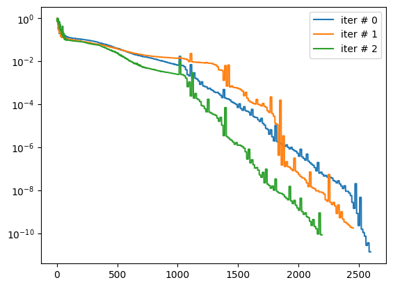

### Plot Network model with absolute percent errors

To compare the results, we plot the network together with the absolute percent errors (with respect to the classical results) for the predicted pressures and flow rates.

```python
from utils import get_ape_from_pd_series

wntr.graphics.plot_network(
    wn,
    node_attribute=get_ape_from_pd_series(
        results_vqls.node["pressure"].iloc[0], results_epanet.node["pressure"].iloc[0]
    ),
    link_attribute=get_ape_from_pd_series(
        results_vqls.link["flowrate"].iloc[0],
        results_epanet.link["flowrate"].iloc[0],
    ),
    node_colorbar_label="Pressure %",
    link_colorbar_label="Flows %",
    node_size=150,
    title=f"{inp_file}: Absolute Percent Error",
    node_labels=True,
    link_labels=True,
    node_alpha=0.5,
)
```

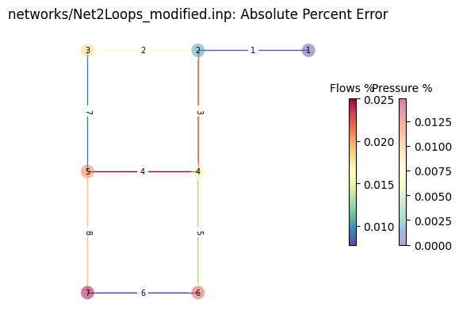

### Plot pressures and flow rates

Let's check graphically the equivalence of the results.

```python
import matplotlib.pyplot as plt
from mpl_toolkits.axes_grid1.inset_locator import inset_axes

fig, ax = plt.subplots()
ax.scatter(
    results_classical[:n_pipes],
    results_quantum[:n_pipes],
    label="Flow rates",
    color="blue",
    marker="o",
)
ax.scatter(
    results_classical[n_pipes:],
    results_quantum[n_pipes:],
    label="Pressures",
    color="red",
    marker="s",
    facecolors="none",
)
ax.axline((0, 0), slope=1, linestyle="--", color="gray", label="")
ax.set_xlabel("Classical results")
ax.set_ylabel("Quantum results")
ax.legend()

# inset plot
ax_inset = inset_axes(ax, width="35%", height="35%", loc="lower right")
ax_inset.scatter(
    results_classical[:n_pipes], results_quantum[:n_pipes], color="blue", marker="o"
)
ax_inset.scatter(
    results_classical[n_pipes:],
    results_quantum[n_pipes:],
    color="red",
    marker="s",
    facecolors="none",
)
ax_inset.axline((0, 0), slope=1, linestyle="--", color="gray")
ax_inset.set_xlim(-0.25, 0.5)
ax_inset.set_ylim(-0.25, 0.5)
ax_inset.set_xticks([-0.25, 0, 0.5])
ax_inset.set_yticks([-0.25, 0, 0.5])
# plt.legend()
plt.show()

results_classical, results_quantum
```

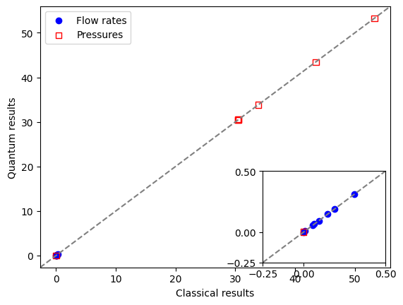

```
([0.31109074,
  0.09356474,
  0.18975493,
  0.009044859,
  0.14737916,
  0.055709664,
  0.06579549,
  -0.00015972625,
  53.247612,
  30.466719,
  43.450195,
  33.808483,
  30.44593,
  30.553486,
  4.3945312e-07],
 [0.31111667,
  0.093549564,
  0.18979658,
  0.009042595,
  0.14740083,
  0.055714004,
  0.065789424,
  -0.00015969579,
  53.24657,
  30.46951,
  43.447197,
  33.81241,
  30.442118,
  30.548964,
  4.3945312e-07])
```